Behavioral Science · Applied Learning · Research & Evaluation

# Zoe Finiasz, Ph.D.

I’m a behavioral scientist who studies how people learn what they believe. Small details, like how a sentence is phrased or who is saying it, can change what people understand. My work looks for the details that make the biggest difference for learners. I also test whether programs designed to support learners actually work.

zfiniasz@gmail.com [LinkedIn](https://www.linkedin.com/in/zoe-finiasz/) [resume (PDF)](https://drive.google.com/file/d/1naWusbUd_WFw_cvgHnXuFRsHi2Pc4_r8/view?usp=drive_link)

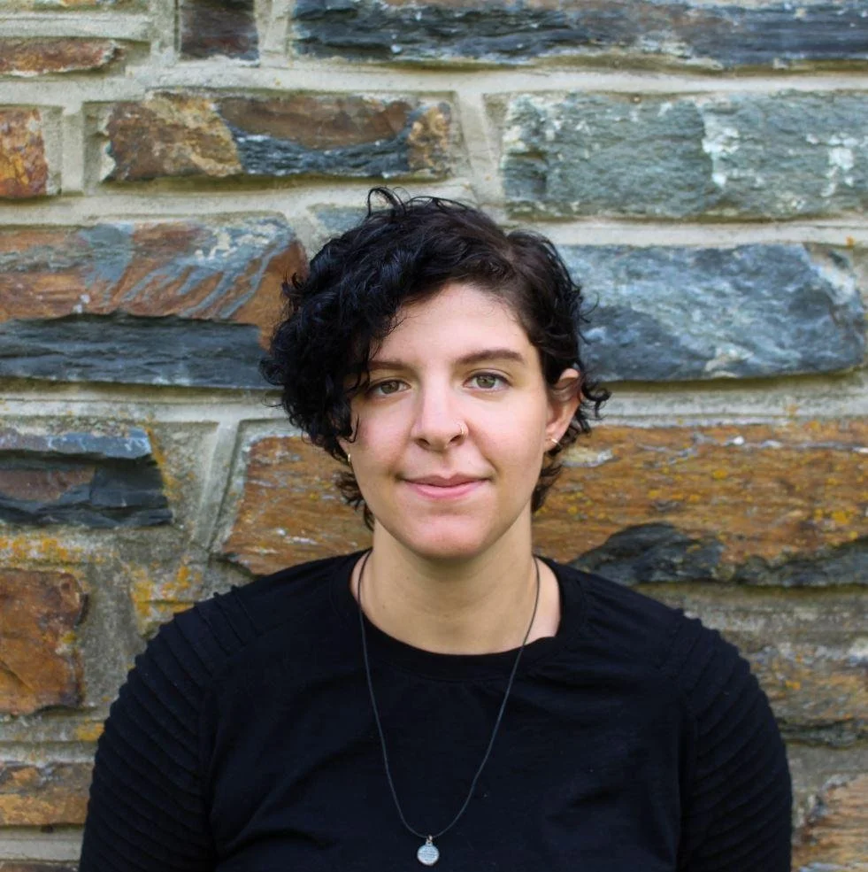

Featured Projects

## Research Case Studies

Each case study covers the question, how the research was done, what I did, and what the findings mean for the people designing products, programs, and experiences.

01

Vaccine Attitudes Survey

Survey DesignAudience SegmentationQualtricsProlificRTableau

Read →

02

Supporting Learning at Science Museums

Field study of 325 families at 3 children’s museums: when kids helped lead play, they explored more systematically — and that exploration predicted what they could rebuild on their own.

Applied LearningQualitative CodingInter-rater Reliability

Read →

03

Designing & Evaluating a Graduate Preview Weekend

Designed and evaluated a selective weekend program for prospective Ph.D. applicants (89 applied, 13 attended): ratings rose on all 12 pre/post survey items, with the largest gains in sense of belonging.

Program DesignPre/Post EvaluationBudget ManagementEvent Logistics

Read →

04

Instructional Language and Learning

Controlled experiments with children and adults: broad, generic phrasing led learners to over-generalize from limited evidence more than specific phrasing did.

RMixed-Effects ModelsRandomized ExperimentsInstructional Design

Read →

More research **How Children Learn From Others** · 63 published studies coded into one dataset to find which assessment design choices change results →

See full publications list →

Data Lab

## Independent Analytics Projects

Where I build skills in SQL, Tableau, and R on real-world data, outside my academic research. Each project has a write-up and the code.

See the full Data Lab log →

In progressStarted Oct 2026

### COVID-19 Vaccination & Health Attitudes

How do vaccine-hesitant and vaccine-supportive adults differ in their values and health habits? A dashboard from my 800-person survey.

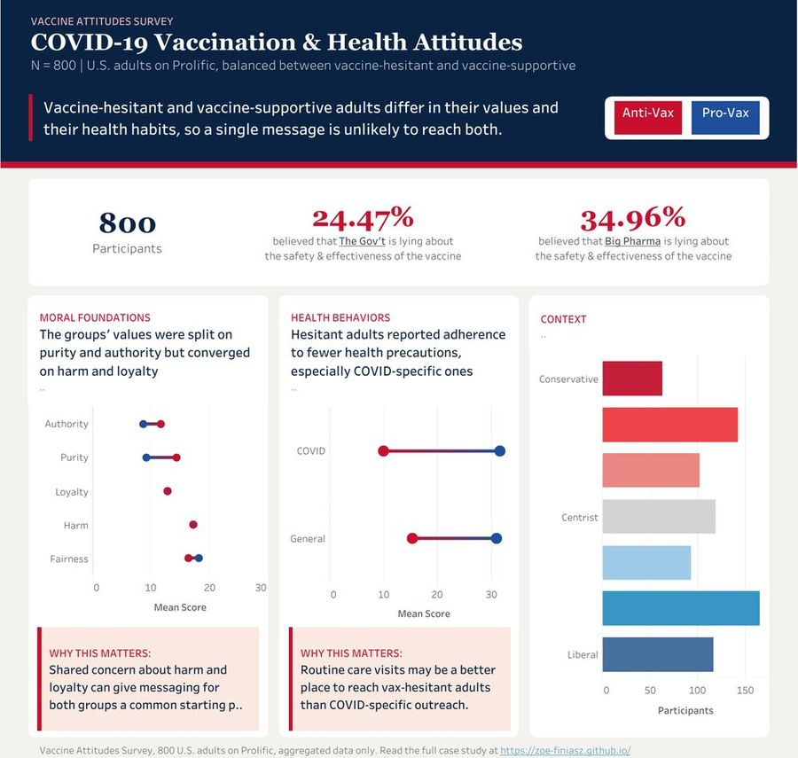

Tableau PublicRSurvey Data

[View the dashboard →](https://public.tableau.com/views/Vax_Data_Respond_Profile/Provs_AntiVaxxers?:language=en-US&:display_count=n&:origin=viz_share_link)Code coming soon

In progressStarted Sep 2026

### Two Decades of Household Purchasing

How did Prime, free shipping, and the pandemic change what one household buys, and how often? Uses de-identified order history from 2004 to 2024.

SQL · DuckDBQuartoRTableau

Read the SQL analysis →[Code →](https://github.com/zoe-finiasz/zoe-finiasz.github.io/blob/main/amazon-sql.qmd)Dashboard coming soon

## Let’s talk

I’m open to roles in learning science, instructional design, assessment, and applied behavioral research. If your team is trying to understand how people learn, what they trust, or whether a program is working, I’d love to hear from you.

zfiniasz@gmail.com [LinkedIn](https://www.linkedin.com/in/zoe-finiasz/) [resume (PDF)](https://drive.google.com/file/d/1naWusbUd_WFw_cvgHnXuFRsHi2Pc4_r8/view?usp=drive_link)